# Example of a computational notebook for data analysis

```r
library(tidyverse) ## data processing
```

In this file, we present a notebook where the contents are organized as if this was the supplementary material to the main paper “Mock study of lemurs life history data from the Duke Lemur Center” (available as `examples/datastudy_r/text/main.odt`). For this reason:

- explanations are kept to a minimum, unless strictly specified, because main text takes care of it
- headers and sub-headers are named after objects mentioned in the main text (e.g. “Table 1”)
- figures or tables supposedly included in the main text (without a “S” prefix added to the figure or table number) are saved in the `examples/datastudy_r/text/figures` and `examples/datastudy_r/text/tables` folders.

## Data

In this example, we explore life history data on 2270 lemur individuals living in the [Duke Lemur Center](https://github.com/rfordatascience/tidytuesday/blob/master/data/2021/2021-08-24/readme.md).

```r
lemurs_rawdf <- readr::read_csv('https://raw.githubusercontent.com/rfordatascience/tidytuesday/master/data/2021/2021-08-24/lemur_data.csv',
                          col_types = cols(
                            .default = col_double(),
                            taxon = col_character(),
                            dlc_id = col_character(),
                            hybrid = col_character(),
                            sex = col_character(),
                            name = col_character(),
                            current_resident = col_character(),
                            stud_book = col_character(),
                            dob = col_date(format = ""),
                            estimated_dob = col_character(),
                            birth_type = col_character(),
                            birth_institution = col_character(),
                            estimated_concep = col_date(format = ""),
                            dam_id = col_character(),
                            dam_name = col_character(),
                            dam_taxon = col_character(),
                            dam_dob = col_date(format = ""),
                            sire_id = col_character(),
                            sire_name = col_character(),
                            sire_taxon = col_character(),
                            sire_dob = col_date(format = ""),
                            dod = col_date(format = ""),
                            age_of_living_y = col_double(), ## this column is typed wrong (as character) by default
                            dob_estimated = col_character(),
                            weight_date = col_date(format = ""),
                            age_category = col_character(),
                            preg_status = col_character(),
                            concep_date_if_preg = col_date(format = ""),
                            infant_dob_if_preg = col_date(format = "")
                            )
)

## key of species name and abbreviation in the taxon columns
lemurs_sppnames_df <- readr::read_csv(file.path(data_dir, "lemurs_sppnames.csv"),
                                      col_names = TRUE)

lemurs_rawdf %>%
  head() %>%
  kableExtra::kbl(caption = "Header of the original data set on the health, reproduction, and social dynamics of lemurs housed at the Duke Lemur Center, in North Carolina, USA.")%>%
  kableExtra::kable_styling(c("striped", "hover")) %>%
  kableExtra::scroll_box(width = "100%", height = "300px")
```

Header of the original data set on the health, reproduction, and social dynamics of lemurs housed at the Duke Lemur Center, in North Carolina, USA.

| taxon | dlc_id | hybrid | sex | name | current_resident | stud_book | dob | birth_month | estimated_dob | birth_type | birth_institution | litter_size | expected_gestation | estimated_concep | concep_month | dam_id | dam_name | dam_taxon | dam_dob | dam_age_at_concep_y | sire_id | sire_name | sire_taxon | sire_dob | sire_age_at_concep_y | dod | age_at_death_y | age_of_living_y | age_last_verified_y | … |
| --- | --- | --- | --- | --- | --- | --- | --- | --- | --- | --- | --- | --- | --- | --- | --- | --- | --- | --- | --- | --- | --- | --- | --- | --- | --- | --- | --- | --- | --- | --- |
| OGG | 0005 | N | M | KANGA | N | NA | 1961-08-25 | 8 | NA | CB | Duke Lemur Center | 1 | 129 | 1961-04-18 | 4 | 0001 | WHITE-TAIL | OGG | 1959-01-28 | 2.22 | 0002 | BRUISER | OGG | 1959-01-28 | 2.22 | 1977-02-07 | 15.47 | NA | NA | … |
| OGG | 0005 | N | M | KANGA | N | NA | 1961-08-25 | 8 | NA | CB | Duke Lemur Center | 1 | 129 | 1961-04-18 | 4 | 0001 | WHITE-TAIL | OGG | 1959-01-28 | 2.22 | 0002 | BRUISER | OGG | 1959-01-28 | 2.22 | 1977-02-07 | 15.47 | NA | NA | … |
| OGG | 0006 | N | F | ROO | N | NA | 1961-03-17 | 3 | NA | CB | Duke Lemur Center | 1 | 129 | 1960-11-08 | 11 | 0001 | WHITE-TAIL | OGG | 1959-01-28 | 1.78 | 0002 | BRUISER | OGG | 1959-01-28 | 1.78 | 1974-10-15 | 13.59 | NA | NA | … |
| OGG | 0006 | N | F | ROO | N | NA | 1961-03-17 | 3 | NA | CB | Duke Lemur Center | 1 | 129 | 1960-11-08 | 11 | 0001 | WHITE-TAIL | OGG | 1959-01-28 | 1.78 | 0002 | BRUISER | OGG | 1959-01-28 | 1.78 | 1974-10-15 | 13.59 | NA | NA | … |
| OGG | 0009 | N | M | POOH BEAR | N | NA | 1963-09-30 | 9 | NA | CB | Duke Lemur Center | 1 | 129 | 1963-05-24 | 5 | 0001 | WHITE-TAIL | OGG | 1959-01-28 | 4.32 | 0007 | HERMIT | OGG | 1959-01-28 | 4.32 | 1974-02-13 | 10.38 | NA | NA | … |
| OGG | 0009 | N | M | POOH BEAR | N | NA | 1963-09-30 | 9 | NA | CB | Duke Lemur Center | 1 | 129 | 1963-05-24 | 5 | 0001 | WHITE-TAIL | OGG | 1959-01-28 | 4.32 | 0007 | HERMIT | OGG | 1959-01-28 | 4.32 | 1974-02-13 | 10.38 | NA | NA | … |

### Pre-processing

The data can be organized temporally, thanks to the `weight_date` and `month_of_weight` variables, which report the full date and the month when the weight was measured, respectively. Moreover, we do not need all the 52 variables that were measured, so let’s create smaller time-series with the variables of interest.

```r
lemurs_smallts <- lemurs_rawdf %>%
  dplyr::mutate_at(vars(name, dam_name, sire_name), stringr::str_to_title) %>%
  dplyr::mutate(year = lubridate::year(weight_date)) %>%
  dplyr::select(c(year, month_of_weight, ## time variables
                  taxon, dlc_id, ## id variables
                  hybrid, sex, name, birth_month, litter_size, concep_month, ## birth variables
                  dam_id, dam_name, dam_name, sire_id, sire_name, sire_taxon, ## parental history variables
                  age_at_death_y, age_of_living_y, age_last_verified_y,
                  age_max_live_or_dead_y, age_at_wt_y, age_category, ## age variables
                  weight_g, avg_daily_wt_change_g, ## weight variables
                  preg_status,
                  n_known_offspring, infant_lit_sz_if_preg)) %>%
  dplyr::rename(month = month_of_weight,
                weight = weight_g,
                avg_d_wt_chg = avg_daily_wt_change_g,
                n_offspring = n_known_offspring) %>%
  dplyr::right_join(lemurs_sppnames_df,., by = "taxon") ## id species
```

## Data analysis

### Table 1

Code to produce Table in main text.

```r
lemurs_smallts %>%
  dplyr::filter(!is.na(infant_lit_sz_if_preg)) %>% ## filter the animals for which this information was available
  dplyr::group_by(dlc_id, species) %>%
  dplyr::summarize(inflt_mean_ind = mean(infant_lit_sz_if_preg)) %>%
  ungroup() %>%
  dplyr::group_by(species) %>%
  dplyr::summarize(inflt_mean = mean(inflt_mean_ind),
                   inflt_sd = sd(inflt_mean_ind),
                   n = n()) %>%
  dplyr::rename(Species = species,
                "Infant litter size (mean)" = inflt_mean,
                "Infant litter size (sd)" = inflt_sd) %>%
  write_csv(., file.path(tabs_dir, "table1_main.csv"))
```

### Figure 1

The summary of seasonality of species was done by filtering individual birth month, and summarizing it per species.

```r
## Filter and organize information on individual birth month
births_df <- lemurs_smallts %>%
  dplyr::select(dlc_id, taxon, birth_month, year) %>%
  dplyr::filter(!is.na(birth_month)) %>%
  dplyr::mutate_at(vars(birth_month),
                   lubridate::month, label = TRUE,
                   locale = Sys.getlocale(category = "LC_CTYPE")) %>% ## id months
  dplyr::right_join(lemurs_sppnames_df,., by = "taxon") %>% ## id species
  dplyr::arrange(taxon, birth_month)

months_fct <- lubridate::month(1:12, label = TRUE, locale = Sys.getlocale(category = "LC_CTYPE"))

births_summdf <- births_df %>%
  unique() %>%
  dplyr::group_by(species, common_name, taxon, birth_month, year) %>%
  dplyr::summarize(n_births = n()) %>%
  ungroup() %>%
  tidyr::pivot_wider(id_cols = c(species, common_name, taxon, year),
                     names_from = birth_month, values_from = n_births) %>%
  tidyr::pivot_longer(all_of(months_fct),
                      names_to = "birth_month", values_to = "n_births")%>%
  ## because strings can't be converted back to months, the following turns out quite cumbersome
  dplyr::mutate_at(vars(birth_month),
                   ~ ordered(.,
                             levels = all_of(months_fct)) %>%
                     as.numeric) %>%
  dplyr::mutate_at(vars(birth_month),
                   lubridate::month, label = TRUE,
                                       locale = Sys.getlocale(category = "LC_CTYPE")) %>%
  dplyr::arrange(year, species, birth_month) %>%
  dplyr::group_by(species, birth_month) %>%
  dplyr::summarize(n_births_mean = mean(n_births, na.rm = TRUE),
                 n_births_sd = sd(n_births, na.rm = TRUE))

births_summfig <- births_summdf  %>%
  ggplot(aes(x = birth_month, y = n_births_mean, fill = species)) +
  geom_bar(alpha=0.6, stat = "identity") +
  facet_wrap(~species, ncol = 3) +
  labs(x = "Month", y = "Number of births (mean)") +
  theme(legend.position = "none",
        axis.text.x = element_text(angle = 45))

ggsave(plot = births_summfig, filename = file.path(figs_dir, "figure_1_main.png"),
       width = 19, height = 19, unit = "cm", dpi = 500)
```

### Figure S1

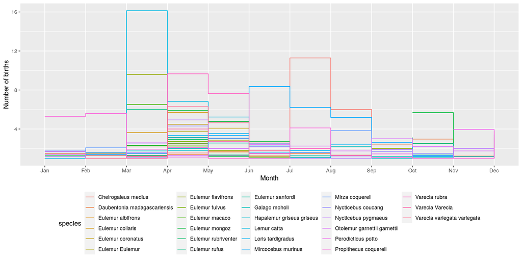

```r
births_summdf %>%
  ggplot(aes(x = birth_month, y = n_births_mean, colour = species, group = species)) +
  geom_step() +
  labs(x = "Month", y = "Number of births") +
  theme(legend.position = "bottom")
```

### Table S1

```r
lemurs_smallts %>%
  dplyr::select(species, sex, preg_status,
                infant_lit_sz_if_preg) %>%
  dplyr::filter(sex == "F", preg_status == "P") %>%
  dplyr::group_by(species) %>%
  dplyr::summarise(mean_litter = mean(infant_lit_sz_if_preg)) %>%
  kableExtra::kbl(caption = "Individual cumulative offspring production and infant litter size of pregant individuals.")%>%
  kableExtra::kable_styling(c("striped", "hover")) %>%
  kableExtra::scroll_box(width = "100%", height = "600px")
```

| species | mean_litter |
| --- | --- |
| Cheirogaleus medius | 1.812500 |
| Daubentonia madagascariensis | NA |
| Eulemur albifrons | 1.000000 |
| Eulemur collaris | 1.000000 |
| Eulemur coronatus | 1.111111 |
| Eulemur Eulemur | 1.000000 |
| Eulemur flavifrons | NA |
| Eulemur fulvus | 1.000000 |
| Eulemur macaco | 1.066667 |
| Eulemur mongoz | 1.011494 |
| Eulemur rubriventer | NA |
| Eulemur rufus | 1.285714 |
| Eulemur sanfordi | 1.000000 |
| Galago moholi | 1.250000 |
| Hapalemur griseus griseus | 1.148936 |
| Lemur catta | 1.563107 |
| Loris tardigradus | 1.000000 |
| Mircocebus murinus | 2.149533 |
| Mirza coquereli | 1.600000 |
| Nycticebus coucang | NA |
| Nycticebus pygmaeus | 1.750000 |
| Otolemur garnettii garnettii | 1.243243 |
| Perodicticus potto | 1.000000 |
| Propithecus coquereli | NA |
| Varecia rubra | 2.044776 |
| Varecia Varecia | 2.000000 |
| Varecia variegata variegata | 2.000000 |